# Supervised Learning - Foundations Project: ReCell

## Problem Statement

### Business Context

Buying and selling used phones and tablets used to be something that happened on a handful of online marketplace sites. But the used and refurbished device market has grown considerably over the past decade, and a new IDC (International Data Corporation) forecast predicts that the used phone market would be worth \$52.7bn by 2023 with a compound annual growth rate (CAGR) of 13.6% from 2018 to 2023. This growth can be attributed to an uptick in demand for used phones and tablets that offer considerable savings compared with new models.

Refurbished and used devices continue to provide cost-effective alternatives to both consumers and businesses that are looking to save money when purchasing one. There are plenty of other benefits associated with the used device market. Used and refurbished devices can be sold with warranties and can also be insured with proof of purchase. Third-party vendors/platforms, such as Verizon, Amazon, etc., provide attractive offers to customers for refurbished devices. Maximizing the longevity of devices through second-hand trade also reduces their environmental impact and helps in recycling and reducing waste. The impact of the COVID-19 outbreak may further boost this segment as consumers cut back on discretionary spending and buy phones and tablets only for immediate needs.

### Objective

The rising potential of this comparatively under-the-radar market fuels the need for an ML-based solution to develop a dynamic pricing strategy for used and refurbished devices. ReCell, a startup aiming to tap the potential in this market, has hired you as a data scientist. They want you to analyze the data provided and build a linear regression model to predict the price of a used phone/tablet and identify factors that significantly influence it.

### Data Description

The data contains the different attributes of used/refurbished phones and tablets. The data was collected in the year 2021. The detailed data dictionary is given below.

- brand_name: Name of manufacturing brand
- os: OS on which the device runs
- screen_size: Size of the screen in cm
- 4g: Whether 4G is available or not
- 5g: Whether 5G is available or not
- main_camera_mp: Resolution of the rear camera in megapixels
- selfie_camera_mp: Resolution of the front camera in megapixels
- int_memory: Amount of internal memory (ROM) in GB
- ram: Amount of RAM in GB
- battery: Energy capacity of the device battery in mAh
- weight: Weight of the device in grams
- release_year: Year when the device model was released
- days_used: Number of days the used/refurbished device has been used
- normalized_new_price: Normalized price of a new device of the same model in euros
- normalized_used_price: Normalized price of the used/refurbished device in euros

## Importing necessary libraries

```python
import pandas as pd           # For data manipulation and analysis
import numpy as np            # For numerical operations
import matplotlib.pyplot as plt       # For data visualization
import seaborn as sns         # For enhanced data visualization
from sklearn.model_selection import train_test_split   # For splitting the data
from sklearn.linear_model import LinearRegression    # For building the linear regression model
from sklearn.metrics import mean_absolute_error, mean_squared_error, r2_score   # For model evaluation
import statsmodels.api as sm    # to build linear regression_model using statsmodels
```

## Loading the dataset

```python
# Load the dataset
data = pd.read_csv('/content/Dataset+-+User+Device+Data.csv')

# Display the first few rows to inspect the data
data.head()
```

|  | brand_name | os | screen_size | 4g | 5g | main_camera_mp | selfie_camera_mp | int_memory | ram | battery | weight | release_year | days_used | normalized_used_price | normalized_new_price |
| --- | --- | --- | --- | --- | --- | --- | --- | --- | --- | --- | --- | --- | --- | --- | --- |
| 0 | Honor | Android | 14.50 | yes | no | 13.0 | 5.0 | 64.0 | 3.0 | 3020.0 | 146.0 | 2020 | 127 | 4.307572 | 4.715100 |
| 1 | Honor | Android | 17.30 | yes | yes | 13.0 | 16.0 | 128.0 | 8.0 | 4300.0 | 213.0 | 2020 | 325 | 5.162097 | 5.519018 |
| 2 | Honor | Android | 16.69 | yes | yes | 13.0 | 8.0 | 128.0 | 8.0 | 4200.0 | 213.0 | 2020 | 162 | 5.111084 | 5.884631 |
| 3 | Honor | Android | 25.50 | yes | yes | 13.0 | 8.0 | 64.0 | 6.0 | 7250.0 | 480.0 | 2020 | 345 | 5.135387 | 5.630961 |
| 4 | Honor | Android | 15.32 | yes | no | 13.0 | 8.0 | 64.0 | 3.0 | 5000.0 | 185.0 | 2020 | 293 | 4.389995 | 4.947837 |

## Data Overview

- Observations
- Sanity checks

```python
# Basic dataset info
print("Number of rows and columns:", data.shape)
print("\nData types:\n", data.dtypes)
```

```
Number of rows and columns: (3454, 15)

Data types:
 brand_name                object
os                        object
screen_size              float64
4g                        object
5g                        object
main_camera_mp           float64
selfie_camera_mp         float64
int_memory               float64
ram                      float64
battery                  float64
weight                   float64
release_year               int64
days_used                  int64
normalized_used_price    float64
normalized_new_price     float64
dtype: object
```

- brand_name, os, 4g and 5g are categorical while all others are numerical data types

```python
# checking column datatypes and number of non-null values
data.info()
```

```
<class 'pandas.core.frame.DataFrame'>
RangeIndex: 3454 entries, 0 to 3453
Data columns (total 15 columns):
 #   Column                 Non-Null Count  Dtype
---  ------                 --------------  -----
 0   brand_name             3454 non-null   object
 1   os                     3454 non-null   object
 2   screen_size            3454 non-null   float64
 3   4g                     3454 non-null   object
 4   5g                     3454 non-null   object
 5   main_camera_mp         3275 non-null   float64
 6   selfie_camera_mp       3452 non-null   float64
 7   int_memory             3450 non-null   float64
 8   ram                    3450 non-null   float64
 9   battery                3448 non-null   float64
 10  weight                 3447 non-null   float64
 11  release_year           3454 non-null   int64
 12  days_used              3454 non-null   int64
 13  normalized_used_price  3454 non-null   float64
 14  normalized_new_price   3454 non-null   float64
dtypes: float64(9), int64(2), object(4)
memory usage: 404.9+ KB
```

- main_camera_mp, selfie_camera_mp, int_memory, ram, battery and weight have missing values, these will be fixed soon
- normalized_used_price is the dependant variable

```python
# Summary statistics for numeric columns
data.describe(include="all").T
```

|  | count | unique | top | freq | mean | std | min | 25% | 50% | 75% | max |
| --- | --- | --- | --- | --- | --- | --- | --- | --- | --- | --- | --- |
| brand_name | 3454 | 34 | Others | 502 | NaN | NaN | NaN | NaN | NaN | NaN | NaN |
| os | 3454 | 4 | Android | 3214 | NaN | NaN | NaN | NaN | NaN | NaN | NaN |
| screen_size | 3454.0 | NaN | NaN | NaN | 13.713115 | 3.80528 | 5.08 | 12.7 | 12.83 | 15.34 | 30.71 |
| 4g | 3454 | 2 | yes | 2335 | NaN | NaN | NaN | NaN | NaN | NaN | NaN |
| 5g | 3454 | 2 | no | 3302 | NaN | NaN | NaN | NaN | NaN | NaN | NaN |
| main_camera_mp | 3275.0 | NaN | NaN | NaN | 9.460208 | 4.815461 | 0.08 | 5.0 | 8.0 | 13.0 | 48.0 |
| selfie_camera_mp | 3452.0 | NaN | NaN | NaN | 6.554229 | 6.970372 | 0.0 | 2.0 | 5.0 | 8.0 | 32.0 |
| int_memory | 3450.0 | NaN | NaN | NaN | 54.573099 | 84.972371 | 0.01 | 16.0 | 32.0 | 64.0 | 1024.0 |
| ram | 3450.0 | NaN | NaN | NaN | 4.036122 | 1.365105 | 0.02 | 4.0 | 4.0 | 4.0 | 12.0 |
| battery | 3448.0 | NaN | NaN | NaN | 3133.402697 | 1299.682844 | 500.0 | 2100.0 | 3000.0 | 4000.0 | 9720.0 |
| weight | 3447.0 | NaN | NaN | NaN | 182.751871 | 88.413228 | 69.0 | 142.0 | 160.0 | 185.0 | 855.0 |
| release_year | 3454.0 | NaN | NaN | NaN | 2015.965258 | 2.298455 | 2013.0 | 2014.0 | 2015.5 | 2018.0 | 2020.0 |
| days_used | 3454.0 | NaN | NaN | NaN | 674.869716 | 248.580166 | 91.0 | 533.5 | 690.5 | 868.75 | 1094.0 |
| normalized_used_price | 3454.0 | NaN | NaN | NaN | 4.364712 | 0.588914 | 1.536867 | 4.033931 | 4.405133 | 4.7557 | 6.619433 |
| normalized_new_price | 3454.0 | NaN | NaN | NaN | 5.233107 | 0.683637 | 2.901422 | 4.790342 | 5.245892 | 5.673718 | 7.847841 |

- There are 34 different manufacturing brands, 4 different operating systems, 4gs or 5gs have either values yes or no for different phones
- Anroid is the most popular os, with 3214 phones running on the same
- 2335 phones have 4g available and only 152 phones have 5g available
- The average values for most numerical data types like screen_size, main_camera_mp, selfie_camera_mp, int_memory, battery, weight are larger than median values, indicating that data may be skewed right
- The average values and median values are almost similar for amount of RAM in GB, indicating very little skwewness, if any
- The average values for number of days used/ refurbished phone has been used, normalized_used_price, normalized_new_price are less than median value, indicating data maybe skewed left

```python
# Percent missing values in each column
round(((data.isnull().sum()/len(data))*100),2)
```

```
brand_name               0.00
os                       0.00
screen_size              0.00
4g                       0.00
5g                       0.00
main_camera_mp           5.18
selfie_camera_mp         0.06
int_memory               0.12
ram                      0.12
battery                  0.17
weight                   0.20
release_year             0.00
days_used                0.00
normalized_used_price    0.00
normalized_new_price     0.00
dtype: float64
```

```python
# Inspect unique values of categorical variables
print("\nUnique values in 'brand_name':\n", data['brand_name'].value_counts())
print("\nUnique values in 'os':\n", data['os'].value_counts())
```

```
Unique values in 'brand_name':
 Others        502
Samsung       341
Huawei        251
LG            201
Lenovo        171
ZTE           140
Xiaomi        132
Oppo          129
Asus          122
Alcatel       121
Micromax      117
Vivo          117
Honor         116
HTC           110
Nokia         106
Motorola      106
Sony           86
Meizu          62
Gionee         56
Acer           51
XOLO           49
Panasonic      47
Realme         41
Apple          39
Lava           36
Celkon         33
Spice          30
Karbonn        29
Coolpad        22
BlackBerry     22
Microsoft      22
OnePlus        22
Google         15
Infinix        10
Name: brand_name, dtype: int64

Unique values in 'os':
 Android    3214
Others      137
Windows      67
iOS          36
Name: os, dtype: int64
```

```python
df = data.copy()
```

## Exploratory Data Analysis (EDA)

- EDA is an important part of any project involving data.
- It is important to investigate and understand the data better before building a model with it.
- A few questions have been mentioned below which will help you approach the analysis in the right manner and generate insights from the data.
- A thorough analysis of the data, in addition to the questions mentioned below, should be done.

**Questions**:

1. What does the distribution of normalized used device prices look like?
2. What percentage of the used device market is dominated by Android devices?
3. The amount of RAM is important for the smooth functioning of a device. How does the amount of RAM vary with the brand?
4. A large battery often increases a device's weight, making it feel uncomfortable in the hands. How does the weight vary for phones and tablets offering large batteries (more than 4500 mAh)?
5. Bigger screens are desirable for entertainment purposes as they offer a better viewing experience. How many phones and tablets are available across different brands with a screen size larger than 6 inches?
6. A lot of devices nowadays offer great selfie cameras, allowing us to capture our favorite moments with loved ones. What is the distribution of devices offering greater than 8MP selfie cameras across brands?
7. Which attributes are highly correlated with the normalized price of a used device?

**What does the distribution of normalized used device prices look like?**

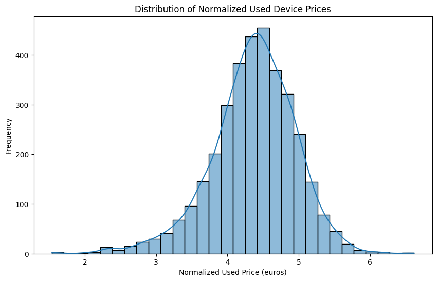

```python
# Create a histogram of the normalized used device prices
plt.figure(figsize=(10, 6))
sns.histplot(data['normalized_used_price'], kde=True, bins=30)
plt.title("Distribution of Normalized Used Device Prices")
plt.xlabel("Normalized Used Price (euros)")
plt.ylabel("Frequency")
plt.show()
```

- The mean normalized_used_price is approx. €4.36 while the median normalized_used_price approx. €4.4 The data is skewed left, indicating several phones have less normalized_used_price

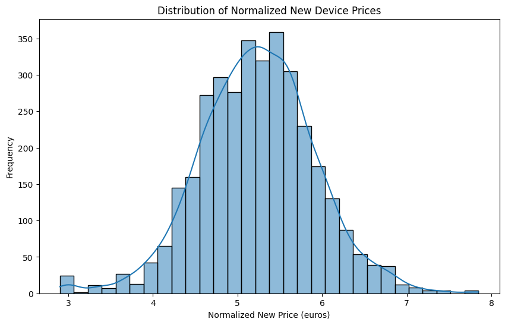

```python
# Create a histogram of the normalized new device prices
plt.figure(figsize=(10, 6))
sns.histplot(data['normalized_new_price'], kde=True, bins=30)
plt.title("Distribution of Normalized New Device Prices")
plt.xlabel("Normalized New Price (euros)")
plt.ylabel("Frequency")
plt.show()
```

```python
def percent(ax, feature):
    total = len(feature)
    for p in ax.patches:
        percentage = '{:.1f}%'.format(100 * p.get_height()/total)
        x = p.get_x() + p.get_width() / 2 - 0.05
        y = p.get_y() + p.get_height()
        ax.annotate(percentage, (x, y), size = 12)
```

- The mean normalized_new_price is approx. €5.23 while the median normalized_new_price is approx. €5.25. The data is also skewed left, indicating some phones have less normalized_new_price

**What percentage of the used device market is dominated by Android devices?**

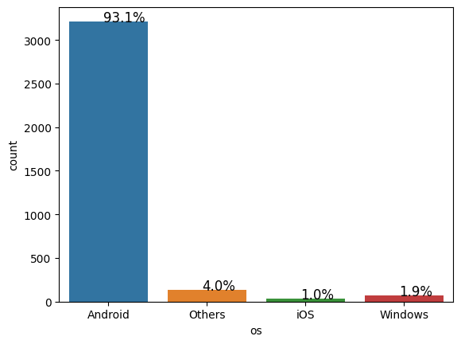

```python
# Distribution of operating systems
ax = sns.countplot(x=df["os"])

percent(ax, df["os"])
```

- More than 90% (93.1%) of the used phone market is dominated by andorid devices

```python
# since android is clearly dominating the os market, we can group others, windows and iOS together
# as a category- "not_Android"

df.loc[df.os=="Others", "os"] = "not_Android"
df.loc[df.os=="Windows", "os"] = "not_Android"
df.loc[df.os=="iOS", "os"] = "not_Android"
```

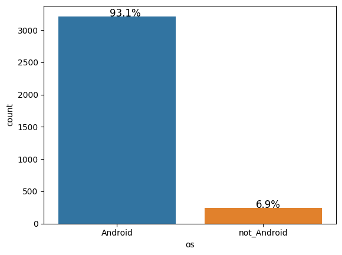

```python
ax = sns.countplot(x=df["os"])

percent(ax, df["os"])
```

**The amount of RAM is important for the smooth functioning of a device. How does the amount of RAM vary with the brand?**

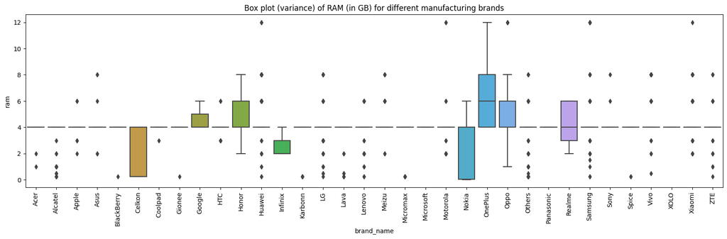

```python
# Distribution of RAM offered by different manufacturing brands
plt.figure(figsize=(20,5))

sns.boxplot(data = df.sort_values("brand_name", ascending=True), x = "brand_name", y="ram");
plt.xticks(rotation=90)
plt.title("Box plot (variance) of RAM (in GB) for different manufacturing brands")
plt.show()
```

- The minimun, 25%, 50%, 75% and maximum RAM (in GB) for several manufacturing brands are the same i.e. 4GB indicating little variance (spread), or absence of a defined "box"plot. However, there are still outliers present (very high or very low RAM (in GB))

**A large battery often increases a device's weight, making it feel uncomfortable in the hands. How does the weight vary for phones and tablets offering large batteries (more than 4500 mAh)?**

```python
# Relation between a phone's weight and battery for phone offering large batteries (more than 4500 mAh)
df_largebatteries = df[df["battery"]>4500]
df_largebatteries.shape
```

```
(341, 15)
```

- There are 341 refurbished phones with large batteries (i.e. >4500 mAh)

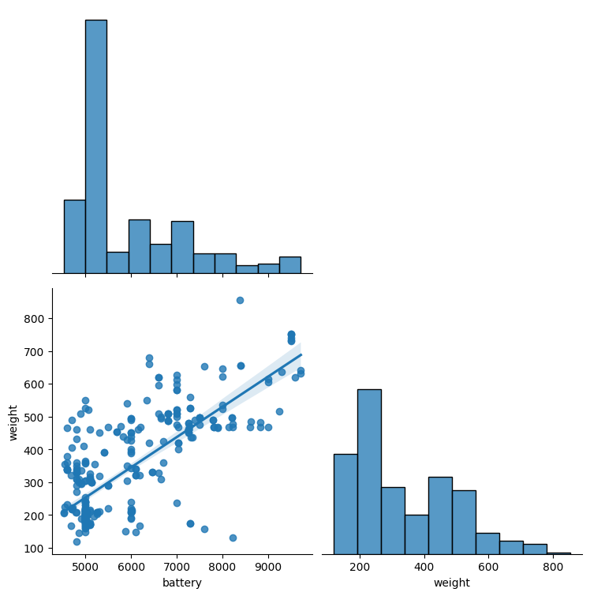

```
Linear correlation factor between phone's weight and battery 0.76
```

```python
g = sns.pairplot(data = df_largebatteries[["battery","weight"]], corner=True, kind="reg")
g.fig.set_size_inches(8,8)
plt.show()
print("Linear correlation factor between phone's weight and battery", \
      round(df_largebatteries.corr()["weight"]["battery"] , 2))
```

- We see a moderate correlation (0.76) between a phone's weight and battery drawing the conclusion that as the battery size increases, so does the weight

**Bigger screens are desirable for entertainment purposes as they offer a better viewing experience. How many phones and tablets are available across different brands with a screen size larger than 6 inches?**

```python
# Distribution of phones with large screen size (>6 inches) offered by different manufacturing brands
#6 inches = 6*2.54cm = 15.24cm
df_largescreen = df[df["screen_size"]>15.24]
df_largescreen.shape
```

```
(1099, 15)
```

- There are 1099 refurbished phones with large screen size (i.e. >6 inches)

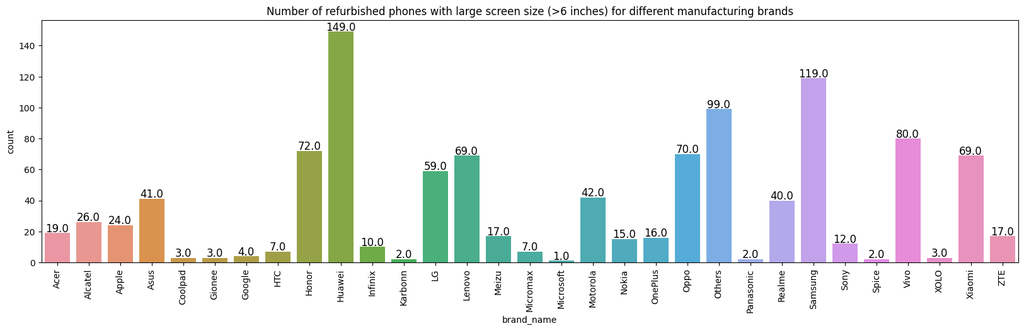

```python
plt.figure(figsize=(20,5))

ax = sns.countplot(data = df_largescreen.sort_values("brand_name", ascending=True), x = "brand_name");
plt.xticks(rotation=90)
plt.title("Number of refurbished phones with large screen size (>6 inches) for different manufacturing brands")
for p in ax.patches:
    label = p.get_height()
    x = p.get_x() + p.get_width() / 2
    y = p.get_height()
    ax.annotate(label,(x, y),ha="center",va="center",size=12,xytext=(0, 5),textcoords="offset points",)
plt.show()
```

**A lot of devices nowadays offer great selfie cameras, allowing us to capture our favorite moments with loved ones. What is the distribution of devices offering greater than 8MP selfie cameras across brands?**

```python
# Distributions of phones with great selfie camera (>8MP) offered by different manufacturing brands
df_greatselfiecamera = df[df["selfie_camera_mp"]>8]
df_greatselfiecamera.shape
```

```
(655, 15)
```

- There are 655 refurbished phones with great selfie cameras (i.e. > 8MP)

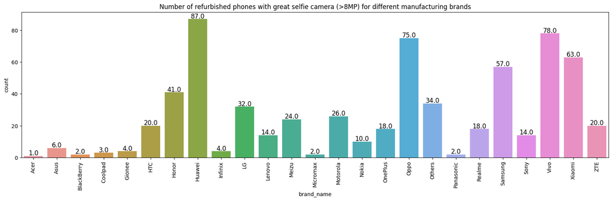

```python
plt.figure(figsize=(20,5))

ax = sns.countplot(data = df_greatselfiecamera.sort_values("brand_name", ascending=True), x = "brand_name");
plt.xticks(rotation=90)
plt.title("Number of refurbished phones with great selfie camera (>8MP) for different manufacturing brands")
for p in ax.patches:
    label = p.get_height()
    x = p.get_x() + p.get_width() / 2
    y = p.get_height()
    ax.annotate(label,(x, y),ha="center",va="center",size=12,xytext=(0, 5),textcoords="offset points",)
plt.show()
```

- Huawei (87 phones), Oppo (75 phones), Vivo (78 phones), Xiaomi (63 phones) and Samsung (57 phones) have some of the highest number of refurbished phones with a great selfie camera (>8MP) - similar brand names observed as for phones with large screen size
- Acer (1 phone), Blackberry/Micromax/Panasonic (2 phones) have some of the lowest number of refurbished phones with a great selfie camera (>8MP)

```python
# We will now bucket the 34 manufacturing brands into 3 categories on the average price of a normalized new phone
# by that manufacturing brand i.e.
# low_range  : <€5
# mid_range  : €5-6
# high_range : >€6


df.groupby("brand_name").mean()["normalized_new_price"].sort_values()
```

```
brand_name
Celkon        4.018319
Spice         4.453086
Micromax      4.513854
Karbonn       4.582536
Lava          4.586627
Infinix       4.655516
Nokia         4.668024
Alcatel       4.804302
XOLO          4.822616
Microsoft     4.963936
Panasonic     5.020892
Others        5.051192
Acer          5.077328
Realme        5.082650
Lenovo        5.138462
Coolpad       5.169676
Motorola      5.191796
ZTE           5.218665
LG            5.286666
BlackBerry    5.304419
Gionee        5.334537
Honor         5.349602
Xiaomi        5.364574
Asus          5.387590
HTC           5.452407
Meizu         5.462516
Samsung       5.482891
Huawei        5.515084
Sony          5.549278
Vivo          5.638037
Oppo          5.679682
Google        6.077932
OnePlus       6.266780
Apple         6.339548
Name: normalized_new_price, dtype: float64
```

```python
df.loc[df.normalized_new_price>0, "brand_name"] = "low_range"
df.loc[df.normalized_new_price>=5, "brand_name"] = "mid_range"
df.loc[df.normalized_new_price>=6, "brand_name"] = "high_range"
```

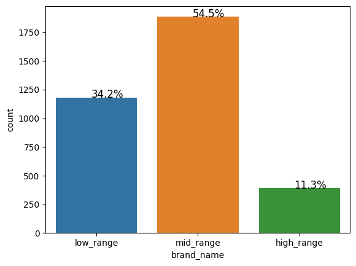

```python
ax = sns.countplot(x=df["brand_name"])

percent(ax, df["brand_name"])
```

- There are now 3 manufacturing brand categories - low_range : 34.2% refurbished phones, mid_range : 54.5% refurbished phones and high_range : 11.3% refurbished phones

**Which attributes are highly correlated with the normalized price of a used device?**

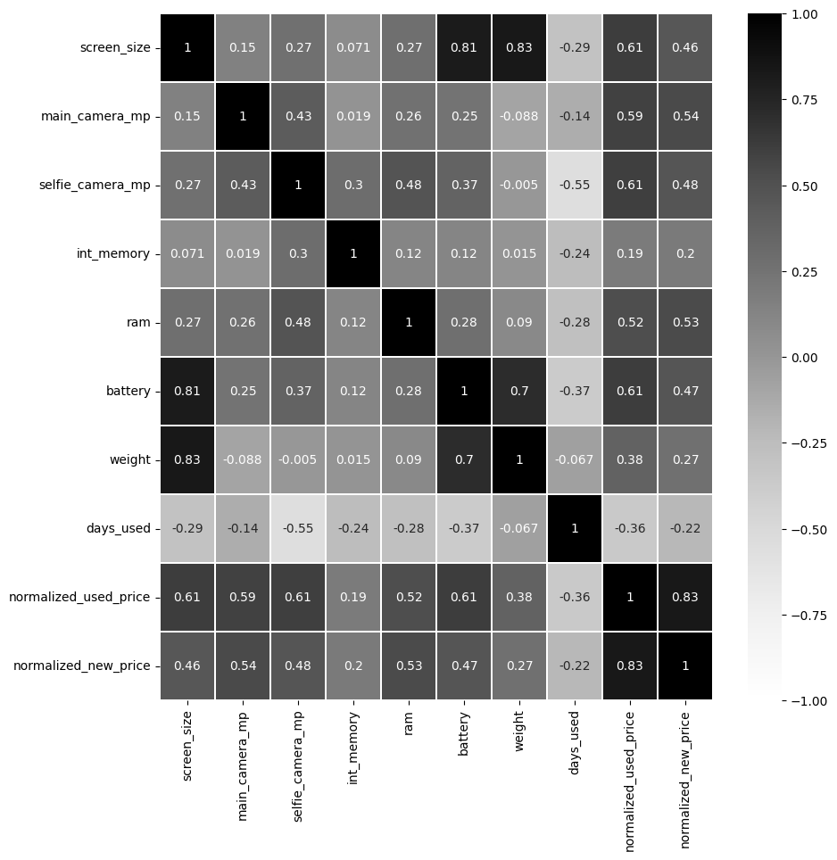

```python
numeric_columns = df.select_dtypes(include=np.number).columns.to_list()
numeric_columns.remove("release_year") #as it is a temporal variable

plt.figure(figsize=(10,10))
sns.heatmap(df[numeric_columns].corr(), annot=True, vmin=-1, vmax=1, cmap="Greys", linewidths=0.05);
```

- screen size is strongly positively correlated with battery (0.81) and weight (0.83)
- selfie camera mp is positively correlated with main camera mp (0.43), ram(0.48)
- normalized used price and normalized new price are positively correlated with screen size (0.61 and 0.46), main camera mp (0.59 and 0.54), selfie camera mp (0.61 and 0.48), ram (0.52 and 0.53), battery (0.61 and 0.47)

## Data Preprocessing

- Missing value treatment
- Feature engineering (if needed)
- Outlier detection and treatment (if needed)
- Preparing data for modeling
- Any other preprocessing steps (if needed)

**Missing value treatment**

```python
df.isnull().sum()
```

```
brand_name                 0
os                         0
screen_size                0
4g                         0
5g                         0
main_camera_mp           179
selfie_camera_mp           2
int_memory                 4
ram                        4
battery                    6
weight                     7
release_year               0
days_used                  0
normalized_used_price      0
normalized_new_price       0
dtype: int64
```

- The dependent variable normalized_used_price does not have any missing values

```python
medianFiller = lambda x:x.fillna(x.median())

brand_names = df["brand_name"].unique()
numeric_column = df.select_dtypes(include = np.number).columns.to_list()

# we will group by brand name (low-range, mid-range or high-range), and for each numeric column, we will replace
# the missing value with the median value of the numeric column of the respective brand name

for item in brand_names:
    df.loc[df.brand_name==item, numeric_column] = \
    df.loc[df.brand_name==item, numeric_column].apply(medianFiller, axis=0)
```

```python
df.isnull().sum()
```

```
brand_name               0
os                       0
screen_size              0
4g                       0
5g                       0
main_camera_mp           0
selfie_camera_mp         0
int_memory               0
ram                      0
battery                  0
weight                   0
release_year             0
days_used                0
normalized_used_price    0
normalized_new_price     0
dtype: int64
```

- All the missing values have been treated.

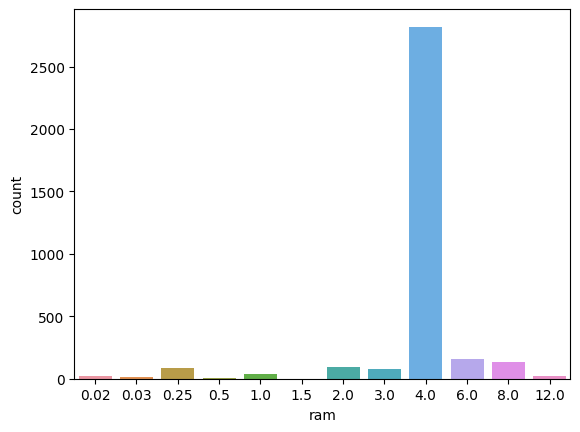

```python
sns.countplot(x=df["ram"])
```

- We will drop "RAM" column as majority of dataset has a constant RAM of 4GB with a few upper and lower outliers.

```python
df.drop("ram", axis=1, inplace=True)
```

```python
numeric_columns.remove("ram")
```

**Outlier detection and treatment**

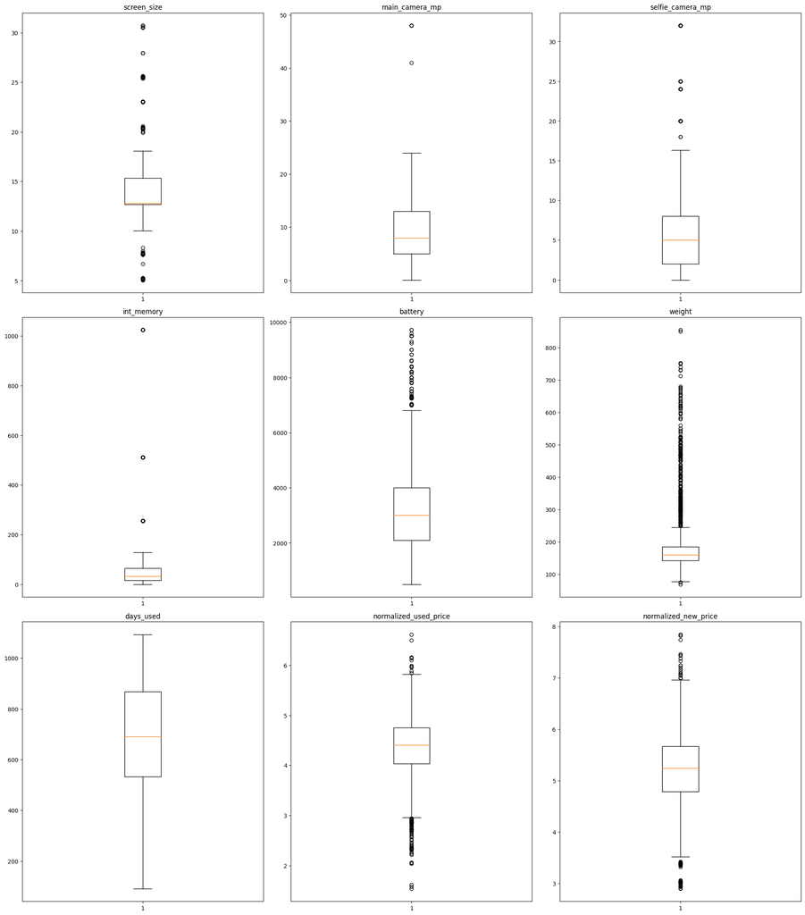

```python
# let's plot the boxplots of all columns to check for outliers

plt.figure(figsize=(20, 30))

for i, variable in enumerate(numeric_columns):
    plt.subplot(4,3, i + 1)
    plt.boxplot(df[variable], whis=1.5)
    plt.tight_layout()
    plt.title(variable)

plt.show()
```

- There are no outliers in the days_used column
- There are a few upper outliers in the main_camera_mp, selfie_camera_mp, int_memory and battery. There are more than a few lower and upper outliers in the screen_size and weight columns
- We will perform flooring and capping to remove these outliers and build our model
- There are some upper and lower outliers in the normalized_new_price independent and normalized_used_price dependent columns

```python
def treat_outliers(df, col):
    Q1 = df[col].quantile(0.25)  # 25th quantile
    Q3 = df[col].quantile(0.75)  # 75th quantile
    IQR = Q3 - Q1
    Lower_Whisker = Q1 - 1.5 * IQR
    Upper_Whisker = Q3 + 1.5 * IQR

    # all the values smaller than Lower_Whisker will be assigned the value of Lower_Whisker
    # all the values greater than Upper_Whisker will be assigned the value of Upper_Whisker
    df[col] = np.clip(df[col], Lower_Whisker, Upper_Whisker)

    return df


def treat_outliers_all(df, col_list):
    for c in col_list:
        df = treat_outliers(df, c)

    return df
```

```python
# treating the outliers
numerical_col = df.select_dtypes(include=np.number).columns.tolist()
df = treat_outliers_all(df, numerical_col)
```

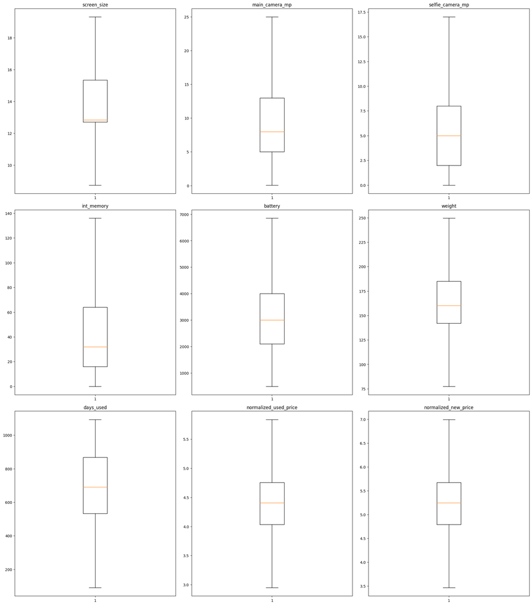

```python
# let's look at the boxplots to see if the outliers have been treated or not
plt.figure(figsize=(20, 30))

for i, variable in enumerate(numeric_columns):
    plt.subplot(4, 3, i + 1)
    plt.boxplot(df[variable], whis=1.5)
    plt.tight_layout()
    plt.title(variable)

plt.show()
```

## EDA

- It is a good idea to explore the data once again after manipulating it.

**Reanalyzing distribution of phones with large screen size (>6 inches), phones with great selfie camera (>8MP), offered by different manufacturing brands**

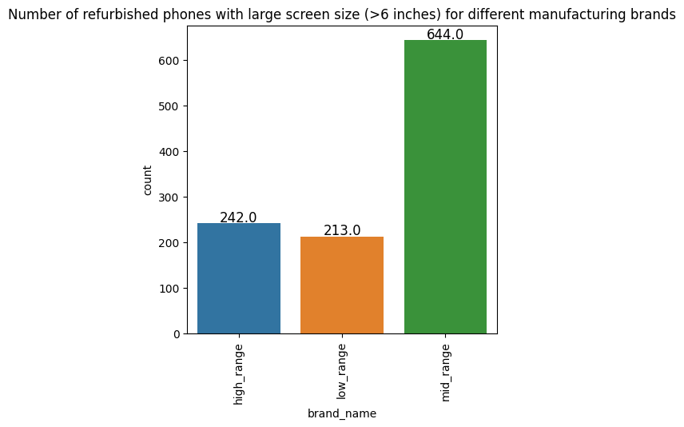

```python
#6 inches = 6*2.54cm = 15.24cm
df_largescreen = df[df["screen_size"]>15.24]

plt.figure(figsize=(5,5))

ax = sns.countplot(data = df_largescreen.sort_values("brand_name", ascending=True), x = "brand_name");
plt.xticks(rotation=90)
plt.title("Number of refurbished phones with large screen size (>6 inches) for different manufacturing brands")
for p in ax.patches:
    label = p.get_height()
    x = p.get_x() + p.get_width() / 2
    y = p.get_height()
    ax.annotate(label,(x, y),ha="center",va="center",size=12,xytext=(0, 5),textcoords="offset points",)
plt.show()
```

- mid_range brands offer maximum number of refurbished phones with large screen size (644 phones), followed by high_range brands (242 phones) and then low_range brands (213 phones)

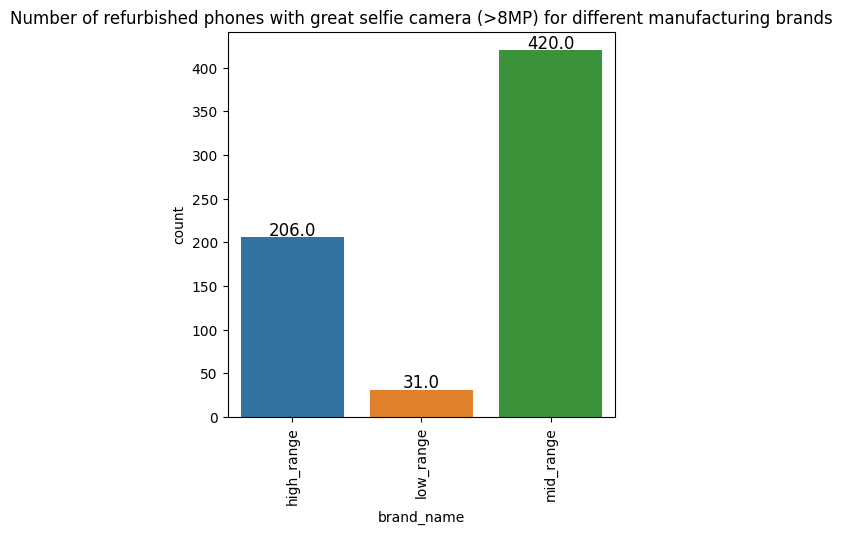

```python
df_greatselfiecamera = df[df["selfie_camera_mp"]>8]

plt.figure(figsize=(5,5))

ax = sns.countplot(data = df_greatselfiecamera.sort_values("brand_name", ascending=True), x = "brand_name");
plt.xticks(rotation=90)
plt.title("Number of refurbished phones with great selfie camera (>8MP) for different manufacturing brands")
for p in ax.patches:
    label = p.get_height()
    x = p.get_x() + p.get_width() / 2
    y = p.get_height()
    ax.annotate(label,(x, y),ha="center",va="center",size=12,xytext=(0, 5),textcoords="offset points",)
plt.show()
```

- We see brands following a similar trend with regards to selfie_camera as for bigger_screen_size (i.e., similar to what was observed before feature engineering)
- mid_range brands offer the maximum number of refurbished phones with great selfie_camera (420 phones), followed by high_range brands (206 phones) and then low_range brands (31 phones)

**Reanalyzing the relation between a phone's weight and battery for phone offering large batteries (more than 4500 mAh)**

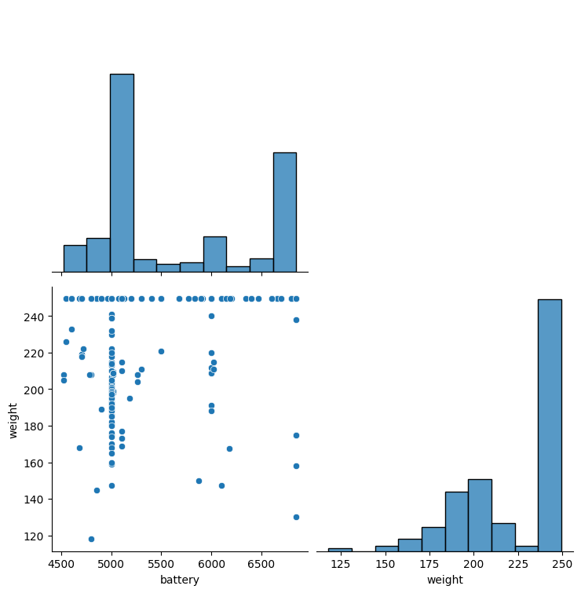

```
Linear correlation factor between phone's weight and battery 0.48
```

```python
df_largebatteries = df[df["battery"]>4500]

g = sns.pairplot(data = df_largebatteries[["battery","weight"]], corner=True)
g.fig.set_size_inches(8,8)
plt.show()
print("Linear correlation factor between phone's weight and battery", \
      round(df_largebatteries.corr()["weight"]["battery"] , 2))
```

- The linear correlation between a phone's weight and battery has dropped from 0.76 to 0.48 after outlier treatment, i.e., has become weaker

**Reanalyzing linear correlation between numerical attributes and normalized :used phone price**

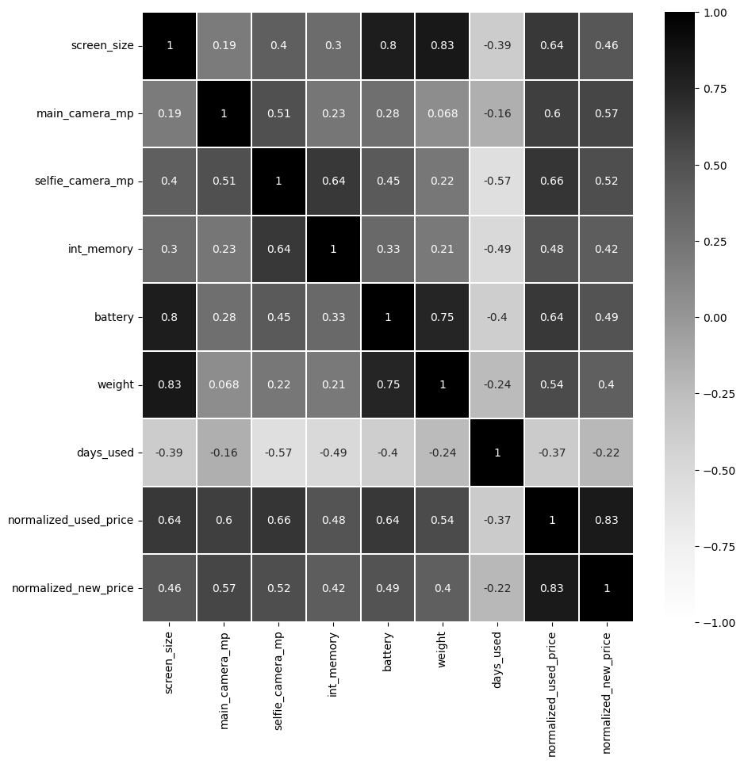

```python
numeric_columns = df.select_dtypes(include=np.number).columns.to_list()
numeric_columns.remove("release_year") #as it is a temporal variable

plt.figure(figsize=(10,10))
sns.heatmap(df[numeric_columns].corr(), annot=True, vmin=-1, vmax=1, cmap="Greys", linewidths=0.05);
```

- normalized_used_price has become marginally more negatively correlated with number of days_used (-0.37 vs. -0.36 before outlier treatment)
- normalized_used_price is still strongly-positively correlated with normalized_new_price ; 0.83 before & after outlier treatment
- The linear correlation with selfie_camera (0.66 vs. 0.61 before), main_camera (0.6 vs. 0.59 before), screen_size (0.64 vs. 0.61 before), battery ( 0.64 vs. 0.61 before) have all increased in comparison to values before outlier treatment

## Model Building - Linear Regression

```python
# defining X and y variables
X = df.drop(["normalized_used_price", "release_year"], axis=1) # since year is a temporal variable
y = df["normalized_used_price"]

print(X.head())
print(y.head())
```

```
  brand_name       os  screen_size   4g   5g  main_camera_mp  \
0  low_range  Android        14.50  yes   no            13.0
1  mid_range  Android        17.30  yes  yes            13.0
2  mid_range  Android        16.69  yes  yes            13.0
3  mid_range  Android        19.30  yes  yes            13.0
4  low_range  Android        15.32  yes   no            13.0

   selfie_camera_mp  int_memory  battery  weight  days_used  \
0               5.0        64.0   3020.0   146.0        127
1              16.0       128.0   4300.0   213.0        325
2               8.0       128.0   4200.0   213.0        162
3               8.0        64.0   6850.0   249.5        345
4               8.0        64.0   5000.0   185.0        293

   normalized_new_price
0              4.715100
1              5.519018
2              5.884631
3              5.630961
4              4.947837
0    4.307572
1    5.162097
2    5.111084
3    5.135387
4    4.389995
Name: normalized_used_price, dtype: float64
```

```python
# encoding categorical variables
X = pd.get_dummies(X, columns=X.select_dtypes(include=["object","category"]).columns.to_list(), \
    drop_first=True)

print(X.shape)
X.head()
```

```
(3454, 13)
```

|  | screen_size | main_camera_mp | selfie_camera_mp | int_memory | battery | weight | days_used | normalized_new_price | brand_name_low_range | brand_name_mid_range | os_not_Android | 4g_yes | 5g_yes |
| --- | --- | --- | --- | --- | --- | --- | --- | --- | --- | --- | --- | --- | --- |
| 0 | 14.50 | 13.0 | 5.0 | 64.0 | 3020.0 | 146.0 | 127 | 4.715100 | 1 | 0 | 0 | 1 | 0 |
| 1 | 17.30 | 13.0 | 16.0 | 128.0 | 4300.0 | 213.0 | 325 | 5.519018 | 0 | 1 | 0 | 1 | 1 |
| 2 | 16.69 | 13.0 | 8.0 | 128.0 | 4200.0 | 213.0 | 162 | 5.884631 | 0 | 1 | 0 | 1 | 1 |
| 3 | 19.30 | 13.0 | 8.0 | 64.0 | 6850.0 | 249.5 | 345 | 5.630961 | 0 | 1 | 0 | 1 | 1 |
| 4 | 15.32 | 13.0 | 8.0 | 64.0 | 5000.0 | 185.0 | 293 | 4.947837 | 1 | 0 | 0 | 1 | 0 |

```python
# splitting the data in 70:30 ratio for train to test data

x_train, x_test, y_train, y_test = train_test_split(X,y,test_size=0.3, random_state=42)
print("Number of rows in train data =", x_train.shape[0])
print("Number of rows in test data =", x_test.shape[0])
```

```
Number of rows in train data = 2417
Number of rows in test data = 1037
```

```python
# fitting the model on the train data (70% of the whole data)

linearregression = LinearRegression()
linearregression.fit(x_train, y_train)
```

```
LinearRegression()
```

```python
# Checking the coefficients and intercept of the model
coef_df = pd.DataFrame(np.append(linearregression.coef_, linearregression.intercept_), \
                       index = x_train.columns.to_list() + ["Intercept"], columns = ["Coefficients"])
coef_df
```

|  | Coefficients |
| --- | --- |
| screen_size | 4.360116e-02 |
| main_camera_mp | 2.119456e-02 |
| selfie_camera_mp | 1.765508e-02 |
| int_memory | 4.442574e-04 |
| battery | 1.779633e-05 |
| weight | 1.133525e-03 |
| days_used | 8.598710e-07 |
| normalized_new_price | 4.328340e-01 |
| brand_name_low_range | 1.072162e-01 |
| brand_name_mid_range | 6.074512e-02 |
| os_not_Android | 3.840752e-02 |
| 4g_yes | 4.281032e-02 |
| 5g_yes | 1.601815e-02 |
| Intercept | 8.393230e-01 |

## Model Performance Check

```python
# function to compute adjusted R-squared
def adj_r2_score(predictors, targets, predictions):
    r2 = r2_score(targets, predictions)
    n = predictors.shape[0]
    k = predictors.shape[1]
    return 1 - ((1 - r2) * (n - 1) / (n - k - 1))

# function to compute MAPE
def mape_score(targets, predictions):
    return np.mean(np.abs(targets - predictions) / targets) * 100

# function to compute different metrics to check performance of a regression model
def model_performance_regression(model, predictors, target):

    # predicting using the independent variables
    pred = model.predict(predictors)

    r2 = r2_score(target, pred)  # to compute R-squared
    adjr2 = adj_r2_score(predictors, target, pred)  # to compute adjusted R-squared
    rmse = np.sqrt(mean_squared_error(target, pred))  # to compute RMSE
    mae = mean_absolute_error(target, pred)  # to compute MAE
    mape = mape_score(target, pred)  # to compute MAPE

    # creating a dataframe of metrics
    df_perf = pd.DataFrame(
        {
            "RMSE": rmse,
            "MAE": mae,
            "R-squared": r2,
            "Adj. R-squared": adjr2,
            "MAPE": mape,
        },
        index=[0],
    )

    return df_perf
```

```python
# checking model performance on train set (seen 70% data)
print("Training Performance\n")
linearregression_train_perf = model_performance_regression(linearregression, x_train, y_train)
linearregression_train_perf
```

```
Training Performance
```

|  | RMSE | MAE | R-squared | Adj. R-squared | MAPE |
| --- | --- | --- | --- | --- | --- |
| 0 | 0.225171 | 0.178484 | 0.841047 | 0.840187 | 4.193192 |

```python
# checking model performance on test set (seen 30% data)
print("Test Performance\n")
linearregression_test_perf = model_performance_regression(
    linearregression, x_test, y_test
)
linearregression_test_perf
```

```
Test Performance
```

|  | RMSE | MAE | R-squared | Adj. R-squared | MAPE |
| --- | --- | --- | --- | --- | --- |
| 0 | 0.221177 | 0.178511 | 0.843074 | 0.84108 | 4.159049 |

**Observations**

- The training R2 is 0.84, indicating that the model explains approx. 84% of the variation in the train data. So, the model is not underfitting
- MAE (0.178, 0.178) and RMSE (0.2251, 0.2211) on the train and test sets are comparable, which shows that the model is not overfitting
- MAE indicates that our current model is able to predict normalized_used_price within a mean error of 0.178 on the test data
- MAPE on the test set suggests we can predict within 4.16% of normalized_used_price

**Linear Regression using statsmodels**

```python
# unlike sklearn, statsmodels does not add a constant to the data on its own
# we have to add the constant manually
x_train1 = sm.add_constant(x_train)
# adding constant to the test data
x_test1 = sm.add_constant(x_test)

olsmod0 = sm.OLS(y_train, x_train1).fit()
print(olsmod0.summary())
```

```
                              OLS Regression Results
=================================================================================
Dep. Variable:     normalized_used_price   R-squared:                       0.841
Model:                               OLS   Adj. R-squared:                  0.840
Method:                    Least Squares   F-statistic:                     978.0
Date:                   Mon, 18 Sep 2023   Prob (F-statistic):               0.00
Time:                           09:54:09   Log-Likelihood:                 173.92
No. Observations:                   2417   AIC:                            -319.8
Df Residuals:                       2403   BIC:                            -238.8
Df Model:                             13
Covariance Type:               nonrobust
========================================================================================
                           coef    std err          t      P>|t|      [0.025      0.975]
----------------------------------------------------------------------------------------
const                    0.8393      0.099      8.498      0.000       0.646       1.033
screen_size              0.0436      0.004     11.714      0.000       0.036       0.051
main_camera_mp           0.0212      0.001     14.428      0.000       0.018       0.024
selfie_camera_mp         0.0177      0.002     11.733      0.000       0.015       0.021
int_memory               0.0004      0.000      2.609      0.009       0.000       0.001
battery                1.78e-05   7.17e-06      2.483      0.013    3.74e-06    3.19e-05
weight                   0.0011      0.000      4.545      0.000       0.001       0.002
days_used             8.599e-07   2.49e-05      0.034      0.972    -4.8e-05    4.97e-05
normalized_new_price     0.4328      0.016     26.567      0.000       0.401       0.465
brand_name_low_range     0.1072      0.032      3.324      0.001       0.044       0.170
brand_name_mid_range     0.0607      0.022      2.786      0.005       0.018       0.103
os_not_Android           0.0384      0.019      2.020      0.043       0.001       0.076
4g_yes                   0.0428      0.014      3.106      0.002       0.016       0.070
5g_yes                   0.0160      0.027      0.591      0.554      -0.037       0.069
==============================================================================
Omnibus:                       94.558   Durbin-Watson:                   2.011
Prob(Omnibus):                  0.000   Jarque-Bera (JB):              138.704
Skew:                          -0.370   Prob(JB):                     7.60e-31
Kurtosis:                       3.911   Cond. No.                     7.76e+04
==============================================================================

Notes:
[1] Standard Errors assume that the covariance matrix of the errors is correctly specified.
[2] The condition number is large, 7.76e+04. This might indicate that there are
strong multicollinearity or other numerical problems.
```

**Observations**

- Positive values of the coefficient show that normalized_used_price increases with the increase of corresponding attribute value
- p-value of a variable indicates if the variable is significant or not. If we consider the significance level to be 0.05 (5%), then any variable with a p-value less than 0.05 would be considered significant

But these variables might contain multicollinearity, which will affect the p-values. So, we need to deal with multicollinearity and check the other assumptions of linear regression first, and then look at the p-values

## Checking Linear Regression Assumptions

- In order to make statistical inferences from a linear regression model, it is important to ensure that the assumptions of linear regression are satisfied.

**TEST FOR MULTICOLLINEARITY**

Variance Inflation Factor (VIF):

- If VIF is between 1 and 5, then there is low multicollinearity
- If VIF is between 5 and 10, we say there is moderate multicollinearity
- If VIF is exceeding 10, it shows signs of high multicollinearity

```python
from statsmodels.stats.outliers_influence import variance_inflation_factor

# we will define a function to check VIF
def checking_vif(predictors):
    vif = pd.DataFrame()
    vif["feature"] = predictors.columns

    # calculating VIF for each feature
    vif["VIF"] = [variance_inflation_factor(predictors.values, i) for i in range(len(predictors.columns))]
    return vif
```

```python
checking_vif(x_train1)
```

|  | feature | VIF |
| --- | --- | --- |
| 0 | const | 462.326654 |
| 1 | screen_size | 5.111132 |
| 2 | main_camera_mp | 2.174275 |
| 3 | selfie_camera_mp | 3.039447 |
| 4 | int_memory | 2.081394 |
| 5 | battery | 3.562259 |
| 6 | weight | 4.378205 |
| 7 | days_used | 1.800647 |
| 8 | normalized_new_price | 5.710057 |
| 9 | brand_name_low_range | 11.187930 |
| 10 | brand_name_mid_range | 5.596141 |
| 11 | os_not_Android | 1.156258 |
| 12 | 4g_yes | 1.957904 |
| 13 | 5g_yes | 1.353203 |

**Removing Multicollinearity**

To remove multicollinearity

1. Drop every column one by one that has a VIF score greater than 5
2. Look at the adjusted R-squared and RMSE of all these models
3. Drop the variable that makes the least change in adjusted R-squared
4. Check the VIF scores again
5. Continue till you get all VIF scores under 5 or approx 5

```python
def treating_multicollinearity(predictors, target, high_vif_columns):
    # empty lists to store adj. R-squared and RMSE values
    adj_r2 = []
    rmse = []

    # build ols models by dropping one of the high VIF columns at a time
    # store the adjusted R-squared and RMSE in the lists defined previously
    for cols in high_vif_columns:
        # defining the new train set
        train = predictors.loc[:, ~predictors.columns.str.startswith(cols)]

        # create the model
        olsmodel = sm.OLS(target, train).fit()

        # adding adj. R-squared and RMSE to the lists
        adj_r2.append(olsmodel.rsquared_adj)
        rmse.append(np.sqrt(olsmodel.mse_resid))

    # creating a dataframe for the results
    temp = pd.DataFrame(
        {
            "col": high_vif_columns,
            "Adj. R-squared after_dropping col": adj_r2,
            "RMSE after dropping col": rmse,
        }
    ).sort_values(by="Adj. R-squared after_dropping col", ascending=False)
    temp.reset_index(drop=True, inplace=True)

    return temp
```

```python
col_list = ["screen_size","normalized_new_price","brand_name_low_range","brand_name_mid_range"]

res = treating_multicollinearity(x_train1, y_train, col_list)
res
```

|  | col | Adj. R-squared after_dropping col | RMSE after dropping col |
| --- | --- | --- | --- |
| 0 | brand_name_mid_range | 0.839737 | 0.226143 |
| 1 | brand_name_low_range | 0.839519 | 0.226297 |
| 2 | screen_size | 0.831131 | 0.232136 |
| 3 | normalized_new_price | 0.793334 | 0.256804 |

```python
col_to_drop = "brand_name_mid_range"
x_train2 = x_train1.loc[:, ~x_train1.columns.str.startswith(col_to_drop)]
x_test2 = x_test1.loc[:, ~x_test1.columns.str.startswith(col_to_drop)]

# Check VIF now
vif = checking_vif(x_train2)
print("VIF after dropping ", col_to_drop)
vif
```

```
VIF after dropping  brand_name_mid_range
```

|  | feature | VIF |
| --- | --- | --- |
| 0 | const | 231.009462 |
| 1 | screen_size | 5.070755 |
| 2 | main_camera_mp | 2.158842 |
| 3 | selfie_camera_mp | 3.038121 |
| 4 | int_memory | 2.000937 |
| 5 | battery | 3.561995 |
| 6 | weight | 4.376434 |
| 7 | days_used | 1.798932 |
| 8 | normalized_new_price | 3.567451 |
| 9 | brand_name_low_range | 2.676180 |
| 10 | os_not_Android | 1.133737 |
| 11 | 4g_yes | 1.954814 |
| 12 | 5g_yes | 1.333972 |

- screen_size has VIF value very slightly greater than 5 (5.07) so it can be taken

The above predictors have no multicollinearity and the assumption is satisfied

**Let's check the model performance**

```python
olsmod1 = sm.OLS(y_train, x_train2).fit()
print(olsmod1.summary())
```

```
                              OLS Regression Results
=================================================================================
Dep. Variable:     normalized_used_price   R-squared:                       0.841
Model:                               OLS   Adj. R-squared:                  0.840
Method:                    Least Squares   F-statistic:                     1056.
Date:                   Mon, 18 Sep 2023   Prob (F-statistic):               0.00
Time:                           09:54:09   Log-Likelihood:                 170.03
No. Observations:                   2417   AIC:                            -314.1
Df Residuals:                       2404   BIC:                            -238.8
Df Model:                             12
Covariance Type:               nonrobust
========================================================================================
                           coef    std err          t      P>|t|      [0.025      0.975]
----------------------------------------------------------------------------------------
const                    1.0340      0.070     14.789      0.000       0.897       1.171
screen_size              0.0445      0.004     11.993      0.000       0.037       0.052
main_camera_mp           0.0215      0.001     14.694      0.000       0.019       0.024
selfie_camera_mp         0.0177      0.002     11.777      0.000       0.015       0.021
int_memory               0.0004      0.000      2.099      0.036    2.31e-05       0.001
battery               1.762e-05   7.18e-06      2.456      0.014    3.55e-06    3.17e-05
weight                   0.0011      0.000      4.484      0.000       0.001       0.002
days_used             3.003e-06   2.49e-05      0.120      0.904   -4.59e-05    5.19e-05
normalized_new_price     0.4050      0.013     31.407      0.000       0.380       0.430
brand_name_low_range     0.0288      0.016      1.825      0.068      -0.002       0.060
os_not_Android           0.0310      0.019      1.645      0.100      -0.006       0.068
4g_yes                   0.0443      0.014      3.214      0.001       0.017       0.071
5g_yes                   0.0070      0.027      0.261      0.794      -0.046       0.060
==============================================================================
Omnibus:                      102.792   Durbin-Watson:                   2.009
Prob(Omnibus):                  0.000   Jarque-Bera (JB):              158.393
Skew:                          -0.379   Prob(JB):                     4.03e-35
Kurtosis:                       3.999   Cond. No.                     5.30e+04
==============================================================================

Notes:
[1] Standard Errors assume that the covariance matrix of the errors is correctly specified.
[2] The condition number is large, 5.3e+04. This might indicate that there are
strong multicollinearity or other numerical problems.
```

**Observations**

- We can see that adj. R-squared has remained same 0.84 for the train set (70% dataset), which shows that the dropped column (brand_name_mid_range) did not have much effect on the model
- As there is no multicollinearity, we can look at the p-values of predictor variables to check their significance
- days_used, brand_new_low_range, os_not_Android, 5g_yes have p-value > 0.05. So, they are not significant and we'll drop them. But sometimes p-values change after dropping a variable. So, we'll not drop all variables at once. Instead, we will do the following:
1. Build a model, check the p-values of the variables, and drop the column with the highest p-value
2. Create a new model without the dropped feature, check the p-values of the variables, and drop the column with the highest p-value
3. Repeat the above two steps till there are no columns with p-value > 0.05

```python
# initial list of columns
cols = x_train2.columns.tolist()

# setting an initial max p-value
max_p_value = 1

while len(cols) > 0:
    # defining the train set
    x_train_aux = x_train2[cols]

    # fitting the model
    model = sm.OLS(y_train, x_train_aux).fit()

    # getting the p-values and the maximum p-value
    p_values = model.pvalues
    max_p_value = max(p_values)

    # name of the variable with maximum p-value
    feature_with_p_max = p_values.idxmax()

    if max_p_value > 0.05:
        cols.remove(feature_with_p_max)
    else:
        break

selected_features = cols
print(selected_features)
```

```
['const', 'screen_size', 'main_camera_mp', 'selfie_camera_mp', 'int_memory', 'battery', 'weight', 'normalized_new_price', '4g_yes']
```

```python
x_train3 = x_train2[selected_features]
x_test3 = x_test2[selected_features]
```

```python
olsmod2 = sm.OLS(y_train, x_train3).fit()
print(olsmod2.summary())
```

```
                              OLS Regression Results
=================================================================================
Dep. Variable:     normalized_used_price   R-squared:                       0.840
Model:                               OLS   Adj. R-squared:                  0.840
Method:                    Least Squares   F-statistic:                     1582.
Date:                   Mon, 18 Sep 2023   Prob (F-statistic):               0.00
Time:                           09:54:09   Log-Likelihood:                 167.04
No. Observations:                   2417   AIC:                            -316.1
Df Residuals:                       2408   BIC:                            -264.0
Df Model:                              8
Covariance Type:               nonrobust
========================================================================================
                           coef    std err          t      P>|t|      [0.025      0.975]
----------------------------------------------------------------------------------------
const                    1.1351      0.044     25.851      0.000       1.049       1.221
screen_size              0.0438      0.004     12.003      0.000       0.037       0.051
main_camera_mp           0.0208      0.001     14.636      0.000       0.018       0.024
selfie_camera_mp         0.0174      0.001     12.217      0.000       0.015       0.020
int_memory               0.0004      0.000      2.618      0.009       0.000       0.001
battery               1.665e-05   7.12e-06      2.338      0.019    2.69e-06    3.06e-05
weight                   0.0011      0.000      4.600      0.000       0.001       0.002
normalized_new_price     0.3910      0.010     39.644      0.000       0.372       0.410
4g_yes                   0.0453      0.014      3.314      0.001       0.018       0.072
==============================================================================
Omnibus:                      102.545   Durbin-Watson:                   2.013
Prob(Omnibus):                  0.000   Jarque-Bera (JB):              160.772
Skew:                          -0.373   Prob(JB):                     1.23e-35
Kurtosis:                       4.020   Cond. No.                     3.24e+04
==============================================================================

Notes:
[1] Standard Errors assume that the covariance matrix of the errors is correctly specified.
[2] The condition number is large, 3.24e+04. This might indicate that there are
strong multicollinearity or other numerical problems.
```

**Now no feature has p-value greater than 0.05, so we'll consider the features in x_train3 as the final ones and olsmod2 as final model**

- Selected features screen_size, main_camera_mp, selfie_camera_mp, int_memory, battery, weight, normalized_new_price, 4g_yes have positive influence on normalized_used_price

**Observations**

- Now adjusted R-squared is 0.840, i.e., our model is able to explain 84% of the variance. This shows that the model is good
- The adjusted R-squared in olsmod0 (where we considered all the variables) was also 0.840. This shows that the variables we dropped were not affecting the model much

**TEST FOR LINEARITY AND INDEPENDENCE**

Check for linearity and independence-

- Make a plot of fitted values vs residuals
- If they don't follow any pattern, then we say the model is linear and residuals are independent
- Otherwise, the model is showing signs of non-linearity and residuals are not independent

```python
# let us create a dataframe with actual, fitted and residual values
df_pred = pd.DataFrame()

df_pred["Actual Values"] = y_train  # actual values
df_pred["Fitted Values"] = olsmod2.fittedvalues  # predicted values
df_pred["Residuals"] = olsmod2.resid  # residuals

df_pred.head()
```

|  | Actual Values | Fitted Values | Residuals |
| --- | --- | --- | --- |
| 1744 | 4.261975 | 4.261564 | 0.000411 |
| 3141 | 4.175156 | 3.817153 | 0.358003 |
| 1233 | 4.117410 | 4.460532 | -0.343122 |
| 3046 | 3.782597 | 3.836538 | -0.053941 |
| 2649 | 3.981922 | 3.938416 | 0.043507 |

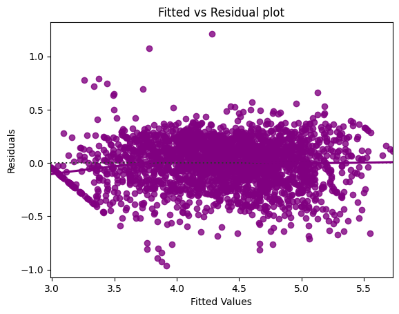

```python
# let's plot the fitted values vs residuals

sns.residplot(data=df_pred, x="Fitted Values", y="Residuals", color="purple", lowess=True)
plt.xlabel("Fitted Values")
plt.ylabel("Residuals")
plt.title("Fitted vs Residual plot")
plt.show()
```

**Assumption is satisfied, hence model is linear and residuals are independent**

**TEST FOR NORMALITY**

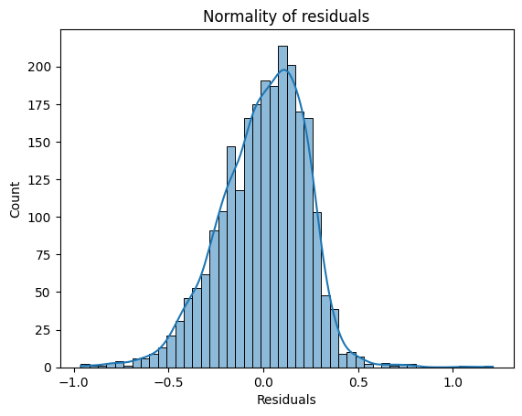

```python
# shape of the histogram of residuals can give an initial idea about the normality
sns.histplot(data=df_pred, x="Residuals", kde=True)
plt.title("Normality of residuals")
plt.show()
```

- From the above graph the shape of histogram of residuals is not perfectly normal

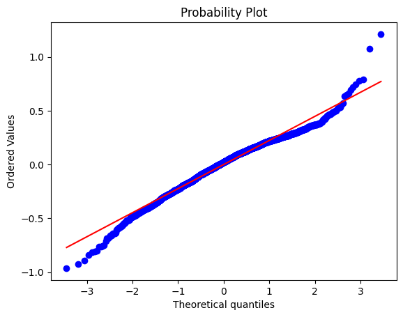

```python
# Q-Q plot of residuals
import pylab
import scipy.stats as stats

stats.probplot(df_pred["Residuals"], dist="norm", plot=pylab)
plt.show()
```

- From the above graph the Q-Q plot of residuals does not follow straight line perfectly

```python
# Shapiro-Wilk test
stats.shapiro(df_pred["Residuals"])
```

```
ShapiroResult(statistic=0.9811267852783203, pvalue=2.2017701639034378e-17)
```

- Since p-value < 0.05, the residuals are not normal as per the Shapiro-Wilk test
- However, as an approximation, we can accept this distribution as close to being normal

**TEST FOR HOMOSCEDASTICITY**

```python
import statsmodels.stats.api as sms
from statsmodels.compat import lzip

name = ["F statistic", "p-value"]
test = sms.het_goldfeldquandt(df_pred["Residuals"], x_train3)
lzip(name, test)
```

```
[('F statistic', 1.0090755878052973), ('p-value', 0.43784807041500395)]
```

**Since p-value > 0.05, we can say that the residuals are homoscedastic. So, this assumption is satisfied**

```python
# predictions on the test set
pred = olsmod2.predict(x_test3)

df_pred_test = pd.DataFrame({"Actual": y_test**(3), "Predicted": pred**(3)})
print("Sample of Actual and Predicted used_price by the ML model (in €)")
df_pred_test.sample(10, random_state=1)
```

```
Sample of Actual and Predicted used_price by the ML model (in €)
```

|  | Actual | Predicted |
| --- | --- | --- |
| 1174 | 94.430815 | 89.396603 |
| 2247 | 81.238798 | 68.905315 |
| 2991 | 73.078043 | 61.069773 |
| 2997 | 79.009214 | 75.336787 |
| 2982 | 100.529127 | 97.764515 |
| 479 | 78.660741 | 74.089413 |
| 17 | 109.011245 | 112.216138 |
| 471 | 105.280149 | 87.370584 |
| 2918 | 90.069046 | 89.228608 |
| 602 | 57.177211 | 70.061811 |

- We can observe here that our model has returned good prediction results, and the actual and predicted (used_price) are comparable, although there is further scope for improvement

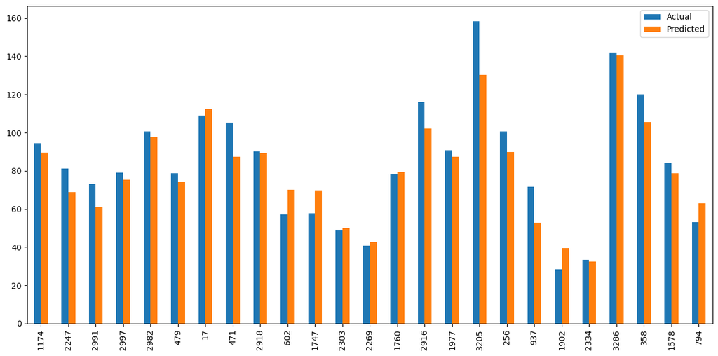

```python
# bar plot to see actual and predicted values
df1 = df_pred_test.sample(25, random_state=1)
df1.plot(kind="bar", figsize=(15, 7))
plt.show()
```

```python
# checking model performance on train set (seen 70% data)
print("Training Performance\n")
olsmod2_train_perf = model_performance_regression(olsmod2, x_train3, y_train)
olsmod2_train_perf
```

```
Training Performance
```

|  | RMSE | MAE | R-squared | Adj. R-squared | MAPE |
| --- | --- | --- | --- | --- | --- |
| 0 | 0.225813 | 0.178442 | 0.840139 | 0.839541 | 4.194385 |

```python
# checking model performance on test set (seen 30% data)
print("Test Performance\n")
olsmod2_test_perf = model_performance_regression(olsmod2, x_test3, y_test)
olsmod2_test_perf
```

```
Test Performance
```

|  | RMSE | MAE | R-squared | Adj. R-squared | MAPE |
| --- | --- | --- | --- | --- | --- |
| 0 | 0.22321 | 0.180015 | 0.840176 | 0.838776 | 4.19907 |

- The model is able to explain ~84% of the variation in the data, which is good
- The train and test RMSE and MAE (~0.22 and ~0.18) are low and comparable. So, our model is not suffering from overfitting
- The MAPE on the test set suggests we can predict within 4.2% of normalized_used_price
- Hence, we can conclude the model olsmod2 is good for prediction as well as inference purposes

**Comparing the initial model created with sklearn and the final statsmodels model**

```python
# training performance comparison

models_train_comp_df = pd.concat(
    [linearregression_train_perf.T, olsmod2_train_perf.T],
    axis=1,
)

models_train_comp_df.columns = [
    "Linear Regression sklearn",
    "Linear Regression statsmodels",
]

print("Training performance comparison:")
models_train_comp_df
```

```
Training performance comparison:
```

|  | Linear Regression sklearn | Linear Regression statsmodels |
| --- | --- | --- |
| RMSE | 0.225171 | 0.225813 |
| MAE | 0.178484 | 0.178442 |
| R-squared | 0.841047 | 0.840139 |
| Adj. R-squared | 0.840187 | 0.839541 |
| MAPE | 4.193192 | 4.194385 |

```python
# test performance comparison

models_test_comp_df = pd.concat(
    [linearregression_test_perf.T, olsmod2_test_perf.T],
    axis=1,
)

models_test_comp_df.columns = [
    "Linear Regression sklearn",
    "Linear Regression statsmodels",
]

print("Test performance comparison:")
models_test_comp_df
```

```
Test performance comparison:
```

|  | Linear Regression sklearn | Linear Regression statsmodels |
| --- | --- | --- |
| RMSE | 0.221177 | 0.223210 |
| MAE | 0.178511 | 0.180015 |
| R-squared | 0.843074 | 0.840176 |
| Adj. R-squared | 0.841080 | 0.838776 |
| MAPE | 4.159049 | 4.199070 |

* The performance of the two models is close to each other

## Final Model

```python
olsmodel_final = sm.OLS(y_train, x_train3).fit()
print(olsmodel_final.summary())
```

```
                              OLS Regression Results
=================================================================================
Dep. Variable:     normalized_used_price   R-squared:                       0.840
Model:                               OLS   Adj. R-squared:                  0.840
Method:                    Least Squares   F-statistic:                     1582.
Date:                   Mon, 18 Sep 2023   Prob (F-statistic):               0.00
Time:                           09:54:12   Log-Likelihood:                 167.04
No. Observations:                   2417   AIC:                            -316.1
Df Residuals:                       2408   BIC:                            -264.0
Df Model:                              8
Covariance Type:               nonrobust
========================================================================================
                           coef    std err          t      P>|t|      [0.025      0.975]
----------------------------------------------------------------------------------------
const                    1.1351      0.044     25.851      0.000       1.049       1.221
screen_size              0.0438      0.004     12.003      0.000       0.037       0.051
main_camera_mp           0.0208      0.001     14.636      0.000       0.018       0.024
selfie_camera_mp         0.0174      0.001     12.217      0.000       0.015       0.020
int_memory               0.0004      0.000      2.618      0.009       0.000       0.001
battery               1.665e-05   7.12e-06      2.338      0.019    2.69e-06    3.06e-05
weight                   0.0011      0.000      4.600      0.000       0.001       0.002
normalized_new_price     0.3910      0.010     39.644      0.000       0.372       0.410
4g_yes                   0.0453      0.014      3.314      0.001       0.018       0.072
==============================================================================
Omnibus:                      102.545   Durbin-Watson:                   2.013
Prob(Omnibus):                  0.000   Jarque-Bera (JB):              160.772
Skew:                          -0.373   Prob(JB):                     1.23e-35
Kurtosis:                       4.020   Cond. No.                     3.24e+04
==============================================================================

Notes:
[1] Standard Errors assume that the covariance matrix of the errors is correctly specified.
[2] The condition number is large, 3.24e+04. This might indicate that there are
strong multicollinearity or other numerical problems.
```

## Actionable Insights and Recommendations

**Conclusion**

**Business Recommendations**